# T21 PROECT

# Aim

Develop methods to identify shared mechanisms between complex diseases and molecular changes in T21.

# Hypthesis

Our working hypothesis is that T21-induced gene expression produces unique, variable, and cascading effects in gene regulatory networks - following the recently proposed omnigenic model - that manifest in DS co-occurring conditions through mechanisms parallel, but modified, compared to the D21 population. To identify convergence, we will connect machine learning-derived gene expression modules (MLDMs) extracted from public data with genetic associations for co-occurring conditions in T21 and D21.

# Hypthesis - Omnigenic model of complex traits

A central goal of genetics is to understand the links between genetic variation and disease. Intuitively, one might expect disease-causing variants to cluster into key pathways that drive disease etiology. But for complex traits, association signals tend to be spread across most of the genome—including near many genes without an obvious connection to disease.

# Hypthesis - Omnigenic model of complex traits

We propose that gene regulatory networks are sufficiently interconnected such that all genes expressed in disease-relevant cells are liable to affect the functions of core disease-related genes and that most heritability can be explained by effects on genes outside core pathways. We refer to this hypothesis as an ‘‘omnigenic’’ model.

# Hypthesis - Omnigenic model of complex traits

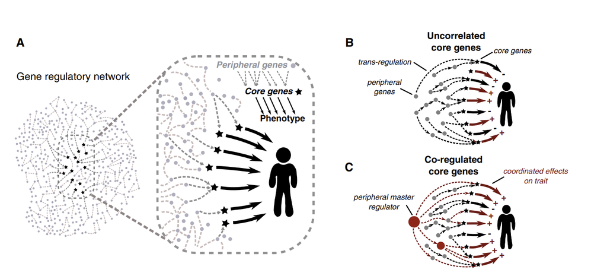

# Hypthesis - Omnigenic model of complex traits

Omnigenic Model: This model posits that the genetic architecture of complex traits involves not only a small number of core genes directly related to a trait but also a vast number of peripheral genes that exert their effects through regulatory networks. This framework suggests that virtually all genes expressed in disease-relevant tissues could contribute to the heritability of complex traits, albeit indirectly.

According to the omnigenic model, the heritability of complex traits is distributed across many genes, including those not directly involved in the disease processes but influencing the trait through complex gene networks. This challenges the traditional focus on identifying “candidate genes” and highlights the importance of considering broad regulatory networks.

This hypothesis aligns with the omnigenic model of complex traits, which posits that a few “core” genes in relevant biological pathways and a plethora of “peripheral” genes, which are indirectly involved through gene regulatory networks, contribute to the genetic architecture of complex diseases and traits.

By leveraging machine learning to extract gene expression modules (MLDMs) from public datasets, we propose to identify clusters of genes whose expression patterns are altered in T21. This method mirrors the omnigenic model’s emphasis on gene networks dissecting the complex regulatory landscapes altered in DS.

Identification of Convergence: A core goal of your project is to identify points of convergence where T21-induced gene expression changes intersect with genetic associations for DS co-occurring conditions. This could reveal core and peripheral genes within DS-specific regulatory networks that are crucial for the development of comorbid conditions, in line with the omnigenic model.

Omnigenic model’s framework could provide a comprehensive understanding of DS and its associated conditions by showing how a wide network of genes contributes to the phenotype. This approach could not only elucidate the genetic basis of DS comorbidities but also potentially inform targeted therapeutic strategies.

Expansion of the Omnigenic Model: Lastly, by applying the omnigenic model to DS, a condition with a clear genetic origin (an extra copy of chromosome 21), your project might extend the model’s applicability beyond polygenic traits to chromosomal abnormalities. This could offer new insights into the flexibility and adaptability of gene regulatory networks in response to significant genomic alterations.

3. Exploring Network Adaptability: By applying the omnigenic model to DS, researchers can explore how gene regulatory networks adapt to the presence of an entire extra chromosome. This adaptation could involve changes in gene expression patterns, alterations in the interactions between genes, and shifts in the roles of both core and peripheral genes. Understanding these adaptations could reveal new dimensions of how genetic disorders manifest and lead to complex phenotypes, offering insights into the resilience and limitations of gene networks in the face of chromosomal abnormalities.
4. Implications for Other Chromosomal Conditions: While DS provides a clear case for studying the impact of chromosomal abnormalities within the omnigenic framework, the insights gained from such research could extend to other conditions caused by chromosomal duplications, deletions, or rearrangements. The adaptability and flexibility of gene regulatory networks in response to these abnormalities could illuminate new pathways for therapeutic intervention, potentially leading to treatments that target the regulatory networks themselves rather than individual genes.
5. New Avenues for Genetic Research: Extending the omnigenic model to include conditions like DS opens new avenues for genetic research, emphasizing the need to consider the entire genome—its regulatory networks and the dynamic interactions between genes—when investigating the genetic basis of any condition, whether polygenic or resulting from chromosomal abnormalities. This approach could lead to a more nuanced understanding of genetic disorders, moving beyond the search for causative genes to explore the systemic impacts of genomic alterations on cellular function and disease phenotypes.

Conclusion Your project proposes a novel application of the omnigenic model to understand the complex genetic landscape of DS and its co-occurring conditions. By focusing on the cascading effects of T21-induced gene expression changes within gene regulatory networks, your hypothesis aims to uncover the underlying mechanisms that contribute to the diverse phenotypic manifestations of DS. This approach not only has the potential to advance our understanding of DS but also could contribute to the broader application of the omnigenic model to a range of genetic conditions.

# Objectives

# Hypthesis

Our working hypothesis is that T21-induced gene expression produces unique, variable, and cascading effects in gene regulatory networks - following the recently proposed omnigenic model - that manifest in DS co-occurring conditions through mechanisms parallel, but modified, compared to the D21 population. To identify convergence, we will connect machine learning-derived gene expression modules (MLDMs) extracted from public data with genetic associations for co-occurring conditions in T21 and D21.

that’s my hypothesis of the project, combine this with the Omnigenic model of complex traits

## Prove python

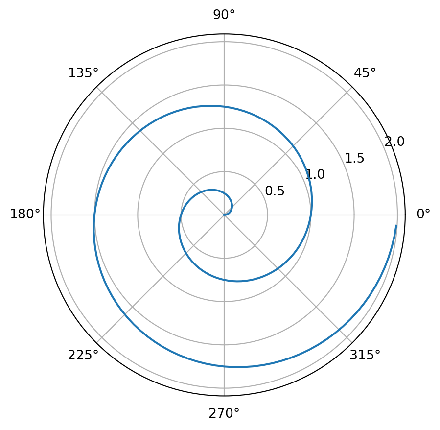

Figure 1: A line plot on a polar axis